# BCR + GEX Integration Tutorial – Part 3: Repertoire Visualization

Clonality donuts, phylogenetic trees, and shared clone analysis

Nachi Nathan

2026-05-21

# Prerequisites

Before running this part, the following must be in place.

**Input files required**

| File | Where it comes from |
| --- | --- |
| `P1_LN_bcr_data.tsv` | Part 1 output, or download from Zenodo: https://zenodo.org/records/20324083 |
| `P1_PT_bcr_data.tsv` | Part 1 output, or download from Zenodo: https://zenodo.org/records/20324083 |
| `integrated_S7_annotated.rds` | Part 2 output, or download from Zenodo: https://zenodo.org/records/20324083 |
| `BCR_viz_functions.R` | This tutorial repo, at `ROOT_DIR/` |

**IQ-TREE 2 (required for phylogenetic trees only)** The tree section uses the dowser package, which calls IQ-TREE 2 externally to build the tree topology. IQ-TREE 2 must be installed before running Section 8.4. The donut plot sections (8.1–8.3) and all of Step 9 do not require IQ-TREE and can be run independently.

1. Download the IQ-TREE 2 binary for your operating system from: https://github.com/Cibiv/IQ-TREE/releases (look for the latest release and download the zip for your OS)
2. Unzip and note the path to the executable:
   - Windows: `C:/tools/iqtree2/bin/iqtree2.exe`
   - macOS/Linux: `/usr/local/bin/iqtree2`
3. Either add the bin folder to your system PATH so it can be called as `iqtree2`, or supply the full path to the `exec` argument in `build_bcr_trees()` as shown in Section 8.4.

**R packages required**

```r
install.packages(c("dplyr", "ggplot2", "data.table", "writexl", "tibble",
                   "tidyr", "patchwork", "scales", "stringr",
                   "dowser", "ape", "RColorBrewer", "ggraph"))
install.packages("Seurat")
# scRepertoire
if (!requireNamespace("BiocManager", quietly = TRUE))
  install.packages("BiocManager")
BiocManager::install("scRepertoire")
# ggtree is on Bioconductor -- cannot be installed with install.packages()
BiocManager::install("ggtree")
```

# Overview

This part covers BCR repertoire visualization using two tool ecosystems. Step 8 uses Immcantation and custom functions to visualize clonal structure within each sample – donut plots at the whole-sample, per-isotype, and per-cluster level, followed by germline-rooted phylogenetic trees for the top expanded clones. Step 9 uses scRepertoire to ask a different question: are any clones shared between the LN and PT samples from the same patient?

The dataset comes from Nathan et al., *Immunity* (2026). The two samples used throughout this tutorial – P1_LN and P1_PT – are the lymph node and primary tumor from the same ovarian cancer patient.

# Setup

Set these variables before running anything else. All paths downstream are derived from these.

```r
suppressPackageStartupMessages({
  library(Seurat)
  library(dplyr)
  library(ggplot2)
  library(data.table)
  library(writexl)
  library(tibble)
  library(tidyr)
  library(patchwork)
  library(scales)
  library(stringr)
  library(dowser)
  library(ggtree)
  library(ape)
  library(RColorBrewer)
  library(scRepertoire)
  library(ggraph)
})

# Baseline RNG seed for the session. Individual stochastic chunks (clonalNetwork)
# are also seeded immediately before they run, so they remain reproducible when
# executed in isolation.
set.seed(42)

ROOT_DIR <- "C:/Users/natha/OneDrive/Documents/Immcantation/BCR_Tutorial/Github"

# BCR_viz_functions.R lives in ROOT_DIR alongside the tutorial Rmd files
source(file.path(ROOT_DIR, "BCR_viz_functions.R"))

# Input: integrated annotated Seurat object from Part 2
rds_in <- file.path(ROOT_DIR, "RDS_Objects", "integrated_S7_annotated.rds")

# Input: per-sample BCR TSV files from Part 1
bcr_tsv <- list(
  P1_LN = file.path(ROOT_DIR, "P1_LN", "Output", "P1_LN_bcr_data.tsv"),
  P1_PT = file.path(ROOT_DIR, "P1_PT", "Output", "P1_PT_bcr_data.tsv")
)

# Output: annotated BCR files, summary tables, and plots
out_dir  <- file.path(ROOT_DIR, "BCR_Data", "Annotated")
plot_dir <- file.path(ROOT_DIR, "Plots", "Part3")
rds_dir  <- file.path(ROOT_DIR, "RDS_Objects")
dir.create(out_dir,  recursive = TRUE, showWarnings = FALSE)
dir.create(plot_dir, recursive = TRUE, showWarnings = FALSE)
dir.create(rds_dir,  recursive = TRUE, showWarnings = FALSE)

message("Ready.")
```

```
## Ready.
```

# Step 8: BCR Visualization

## 8.1 Load the annotated Seurat object and extract cell type labels

We load the integrated object from Part 2 and extract the barcode-to-cell-type mapping from its metadata. We only need three columns: the cell barcode, the `cell_type` label, and the `sample_id`. The barcodes in the integrated object carry the sample suffix (e.g. `ACGT...TGCA-1_P1_LN`) because this was appended during Part 2. The BCR `cell_id` column carries the same suffix from Part 1. The join in Step 8.2 therefore works directly without any barcode manipulation.

Not all BCR cells will match a Seurat barcode. Cells that were filtered out during GEX QC (low quality, doublets) in Part 2 are present in the BCR data but absent from the Seurat object. These will have `cell_type = NA` and are retained in the BCR data for completeness. They appear in combined and per-isotype donuts – their BCR sequences are valid – but are excluded from per-cluster donuts and from tree tip labels, since they have no cluster assignment. In this dataset, 87.8% of P1_LN heavy chain cells and 78.1% of P1_PT heavy chain cells matched a Seurat barcode. Match rates vary depending on GEX QC stringency and are expected to be somewhat lower for the tumor sample, where more cells are filtered during QC.

```r
if (!file.exists(rds_in)) {
  stop("Cannot find integrated RDS at:\n  ", rds_in,
       "\nRun Part 2 first.")
}

obj <- readRDS(rds_in)
message("Integrated object loaded: ", ncol(obj), " cells | ",
        length(unique(obj$cell_type)), " cell types")
```

```
## Integrated object loaded: 7957 cells | 10 cell types
```

```r
# Extract barcode -> cell_type table from Seurat metadata
# rownames of @meta.data are the cell barcodes
cell_type_map <- obj@meta.data %>%
  tibble::rownames_to_column("cell_id") %>%
  dplyr::select(cell_id, cell_type, sample_id)

message("Cell type distribution:")
```

```
## Cell type distribution:
```

```r
print(table(cell_type_map$cell_type))
```

```
##
##        Naive    MBC_Basal   MBC_CR2pos MBC_Atypical           GC   GC_Cycling
##          744         2834          450         1550          665          504
##           PC         PC_2  Plasmablast       Unsure
##          727          241          210           32
```

## 8.2 Join cell type onto BCR data

For each sample we load the BCR TSV from Part 1 and left-join the `cell_type` column by `cell_id`. The result is a long-format data frame with one row per contig (heavy and light chains in separate rows). This long format is required by all visualization functions and by dowser for tree building.

We use `data.table::fread()` to load the TSV files. These files can be large and `fread` is substantially faster than `read_tsv` for files stored on OneDrive, which syncs in the background during reading and can cause `read_tsv` to hang for several minutes.

```r
bcr_annotated <- list()

for (sid in names(bcr_tsv)) {

  tsv_path <- bcr_tsv[[sid]]

  if (!file.exists(tsv_path)) {
    stop("Cannot find BCR TSV for ", sid, " at:\n  ", tsv_path,
         "\nRun Part 1 first.")
  }

  message("\n--- Processing: ", sid, " ---")

  # fread is used here rather than read_tsv for speed on OneDrive-backed paths
  bcr <- data.table::fread(tsv_path, sep = "\t", data.table = FALSE)
  message("  BCR contigs loaded: ", nrow(bcr))

  # Filter cell_type_map to this sample and join by cell_id
  ct_this_sample <- dplyr::filter(cell_type_map, sample_id == sid) %>%
    dplyr::select(cell_id, cell_type)

  bcr <- dplyr::left_join(bcr, ct_this_sample, by = "cell_id")

  # Report match rate on heavy chains only (one per cell)
  n_matched   <- sum(!is.na(bcr$cell_type[bcr$locus == "IGH"]))
  n_igh_total <- sum(bcr$locus == "IGH")
  pct_matched <- round(100 * n_matched / n_igh_total, 1)

  message("  Cell type matched: ", n_matched, " / ", n_igh_total,
          " heavy chain cells (", pct_matched, "%)")

  # Match rates below 50% suggest a barcode format mismatch between
  # Part 1 and Part 2. Check that sample suffixes are consistent.
  if (pct_matched < 50) {
    warning("  Less than 50% of heavy chain cells matched to a cell type. ",
            "Check that barcode suffixes are consistent between Part 1 and Part 2.")
  }

  # Cells not in the Seurat object are left as NA -- they were filtered out
  # during GEX QC and have no valid cluster assignment. They are retained in
  # the BCR data because their BCR sequences are valid, but they will be
  # excluded from per-cluster plots and tree tip labels automatically.

  # Compute VDJ duplicate counts within each clone.
  # For each chain, trim the sequence to V-start -> J-end (same coordinates
  # used by the tree builder) and count how many cells in the same clone share
  # an identical VDJ DNA sequence. This becomes Duplicate_DNA_H / _L in the
  # wide-format table and tells you how many cells made the exact same antibody.
  bcr <- bcr %>%
    dplyr::mutate(
      VDJ_DNA = dplyr::if_else(
        !is.na(v_sequence_start) & !is.na(j_sequence_end) &
          v_sequence_start > 0   & j_sequence_end > 0,
        substr(sequence, v_sequence_start, j_sequence_end),
        sequence
      )
    ) %>%
    dplyr::group_by(clone_id, locus, VDJ_DNA) %>%
    dplyr::mutate(
      Duplicate_DNA_H = dplyr::if_else(locus == "IGH",             dplyr::n(), NA_integer_),
      Duplicate_DNA_L = dplyr::if_else(locus %in% c("IGK", "IGL"), dplyr::n(), NA_integer_)
    ) %>%
    dplyr::ungroup() %>%
    dplyr::select(-VDJ_DNA)

  bcr_annotated[[sid]] <- bcr
  message("  Done: ", nrow(bcr), " total contigs | ",
          length(unique(bcr$cell_id[bcr$locus == "IGH"])), " cells with heavy chain")
}
```

```
##
## --- Processing: P1_LN ---
```

```
##   BCR contigs loaded: 4709
```

```
##   Cell type matched: 2084 / 2373 heavy chain cells (87.8%)
```

```
##   Done: 4709 total contigs | 2373 cells with heavy chain
```

```
##
## --- Processing: P1_PT ---
```

```
##   BCR contigs loaded: 8590
```

```
##   Cell type matched: 3362 / 4307 heavy chain cells (78.1%)
```

```
##   Done: 8590 total contigs | 4307 cells with heavy chain
```

### 8.2a Save the annotated long-format BCR data

We save the annotated BCR data for each sample as a TSV. This is the authoritative input for all BCR visualization downstream, and also feeds into Step 9. If you need to re-run any plots without re-loading the Seurat object, you can load these files directly and skip Steps 8.1–8.2.

```r
for (sid in names(bcr_annotated)) {
  out_path <- file.path(out_dir, paste0(sid, "_S8_bcr_annotated.tsv"))
  data.table::fwrite(bcr_annotated[[sid]], file = out_path, sep = "\t")
  message("Saved: ", out_path)
}
```

```
## Saved: C:/Users/natha/OneDrive/Documents/Immcantation/BCR_Tutorial/Github/BCR_Data/Annotated/P1_LN_S8_bcr_annotated.tsv
```

```
## Saved: C:/Users/natha/OneDrive/Documents/Immcantation/BCR_Tutorial/Github/BCR_Data/Annotated/P1_PT_S8_bcr_annotated.tsv
```

### 8.2b Build and save the wide-format summary table

The long-format BCR data has two rows per cell (one for the heavy chain, one for the light chain). For inspection and tabular analysis it is useful to have a single-row-per-cell summary with both chains side by side. We build this here and save it as an Excel file.

The table includes: cell barcode, clone ID, clone size, sample, cell type, isotype, light chain type (kappa/lambda), VDJ duplicate counts for heavy and light chains, somatic hypermutation counts and frequencies for both chains, V/D/J gene calls, and the full nucleotide sequences.

```r
for (sid in names(bcr_annotated)) {

  bcr <- bcr_annotated[[sid]]

  heavy <- bcr %>%
    dplyr::filter(locus == "IGH") %>%
    dplyr::transmute(
      cell_id,
      clone_id,
      clone_count,
      sample_id,
      cell_type,
      isotype        = c_call,
      Duplicate_DNA_H,
      mu_count_H     = mu_count,
      mu_freq_H      = mu_freq,
      v_call_H       = v_call,
      d_call_H       = d_call,
      j_call_H       = j_call,
      sequence_H     = sequence
    )

  light <- bcr %>%
    dplyr::filter(locus %in% c("IGK", "IGL")) %>%
    dplyr::transmute(
      cell_id,
      light_chain = dplyr::case_when(
        locus == "IGK" ~ "Kappa",
        locus == "IGL" ~ "Lambda",
        TRUE           ~ locus
      ),
      Duplicate_DNA_L,
      mu_count_L = mu_count,
      mu_freq_L  = mu_freq,
      v_call_L   = v_call,
      j_call_L   = j_call,
      sequence_L = sequence
    )

  wide <- dplyr::left_join(heavy, light, by = "cell_id") %>%
    dplyr::arrange(dplyr::desc(clone_count))

  out_path <- file.path(out_dir, paste0(sid, "_S8_final_table.xlsx"))
  writexl::write_xlsx(wide, out_path)
  message(sid, ": wide-format table saved (", nrow(wide), " cells) -- ", out_path)
}
```

```
## P1_LN: wide-format table saved (2373 cells) -- C:/Users/natha/OneDrive/Documents/Immcantation/BCR_Tutorial/Github/BCR_Data/Annotated/P1_LN_S8_final_table.xlsx
```

```
## P1_PT: wide-format table saved (4307 cells) -- C:/Users/natha/OneDrive/Documents/Immcantation/BCR_Tutorial/Github/BCR_Data/Annotated/P1_PT_S8_final_table.xlsx
```

## 8.3 Donut plots

Donut plots are one of the most intuitive ways to visualize clonal structure in BCR data. Each slice represents one clone, with arc length proportional to the number of cells in that clone. Singletons (clones with only one cell) are aggregated into a single white arc – they correctly represent the proportion of the repertoire that is non-expanded, but individual singleton clones carry no meaningful information at this level of analysis.

Expanded clones are colored by their dominant heavy chain isotype using the standard palette defined in `BCR_viz_functions.R`, giving an immediate visual read of the isotype composition of the expanded repertoire.

Three levels of granularity are shown:

- **Combined** – one donut for the whole sample showing all clones. Each slice represents one expanded clone colored by its heavy chain isotype; singletons are aggregated into a single white arc. The relative size of the white arc vs the colored arcs gives an immediate read of how clonal the repertoire is.
- **Per isotype** – one donut per isotype, showing clonal structure within each isotype class. Each expanded clone gets a shade within that isotype’s color family; singletons are white.
- **Per cluster** – one donut per annotated cell type, showing the clonal landscape within each population. BCR cells with no Seurat match (NA cell type) are excluded here since they have no cluster assignment. In this dataset, PC clusters show the highest clonality. Naive B cells show the lowest clonality – near-zero expansion is expected for this population. GC clusters can also show substantial expansion. MBC subsets vary.

### 8.3.1 Combined donut – P1_LN

```r
donuts_ln <- plot_combined_donut(bcr_annotated[["P1_LN"]], sample_name = "P1_LN")
```

```
## Building combined donut for: P1_LN
```

```
##   Total cells: 2308 | Expanded clones: 152
```

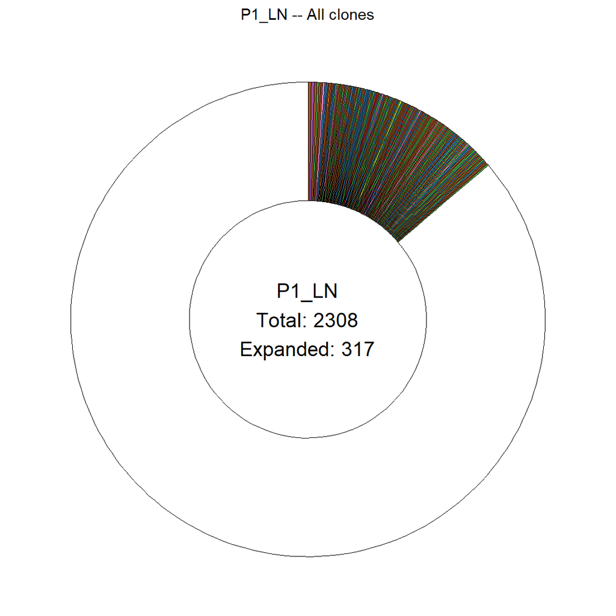

```r
print(donuts_ln$all_clones)
```

### 8.3.2 Combined donut – P1_PT

```r
donuts_pt <- plot_combined_donut(bcr_annotated[["P1_PT"]], sample_name = "P1_PT")
```

```
## Building combined donut for: P1_PT
```

```
##   Total cells: 4063 | Expanded clones: 308
```

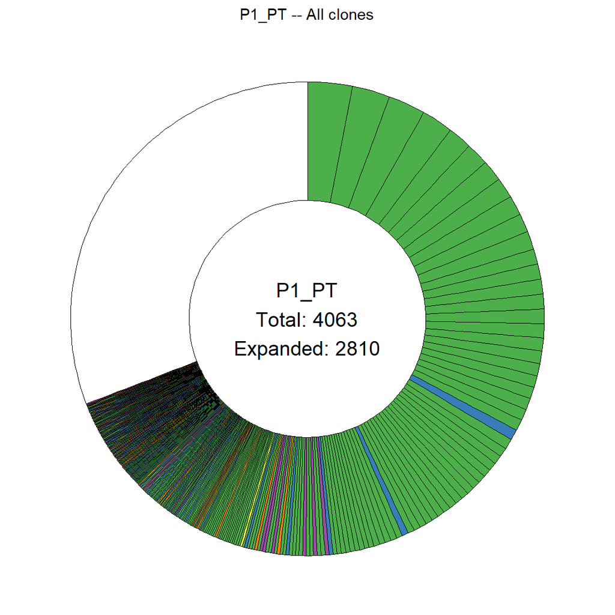

```r
print(donuts_pt$all_clones)
```

### 8.3.3 Per-isotype donuts – P1_LN

Each plot shows the clonal structure within one isotype. Expanded clones are shown in shades of the isotype’s color family (shades of green for IGHG1, shades of blue for IGHM etc.), with darker shades indicating larger clones. Singletons are white. Isotypes with fewer than 5 cells are skipped.

```r
iso_donuts_ln <- plot_isotype_donuts(bcr_annotated[["P1_LN"]], sample_name = "P1_LN")
```

```
## Building per-isotype donuts for: P1_LN
```

```
##   IGHD: 82 cells | 2 expanded clones
```

```
##   IGHM: 749 cells | 33 expanded clones
```

```
##   IGHA1: 728 cells | 67 expanded clones
```

```
##   IGHA2: 179 cells | 7 expanded clones
```

```
##   IGHG1: 499 cells | 38 expanded clones
```

```
##   IGHG2: 78 cells | 3 expanded clones
```

```
##   IGHG3: 35 cells | 1 expanded clones
```

```
##   IGHG4: 13 cells | 1 expanded clones
```

```
## plot_isotype_donuts complete. Isotypes plotted: IGHD, IGHM, IGHA1, IGHA2, IGHG1, IGHG2, IGHG3, IGHG4
```

```r
for (iso in names(iso_donuts_ln)) {
  print(iso_donuts_ln[[iso]]$all_clones)
}
```

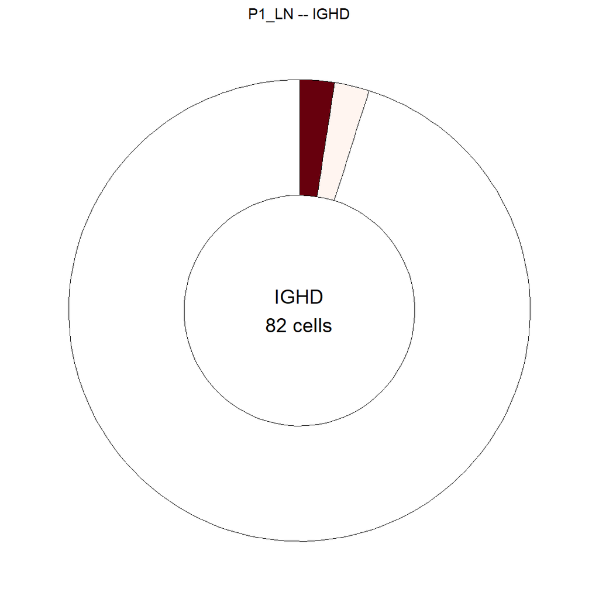

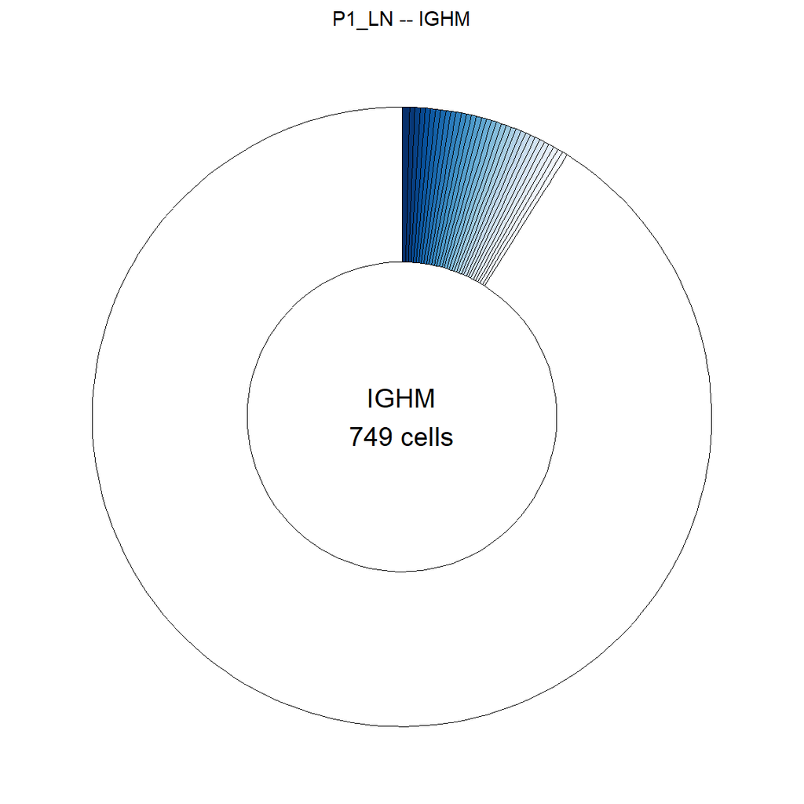

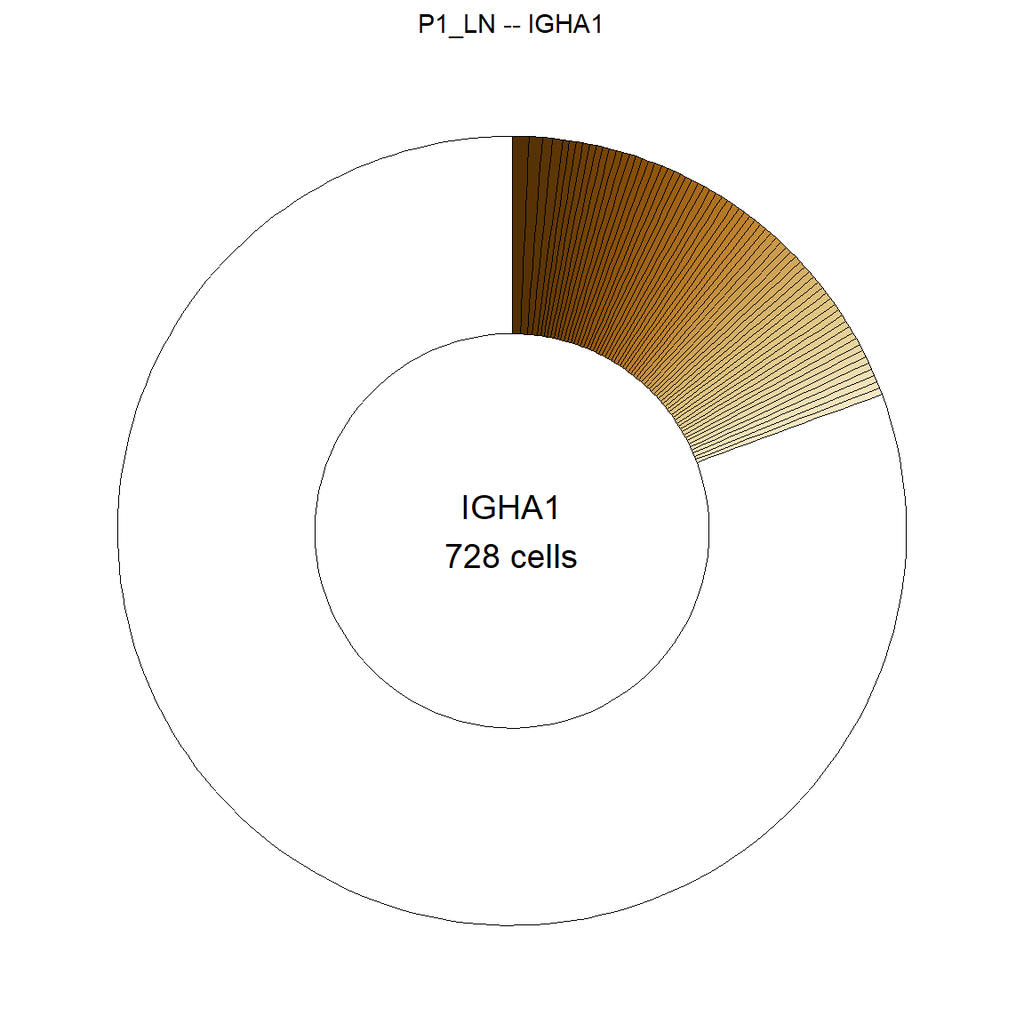

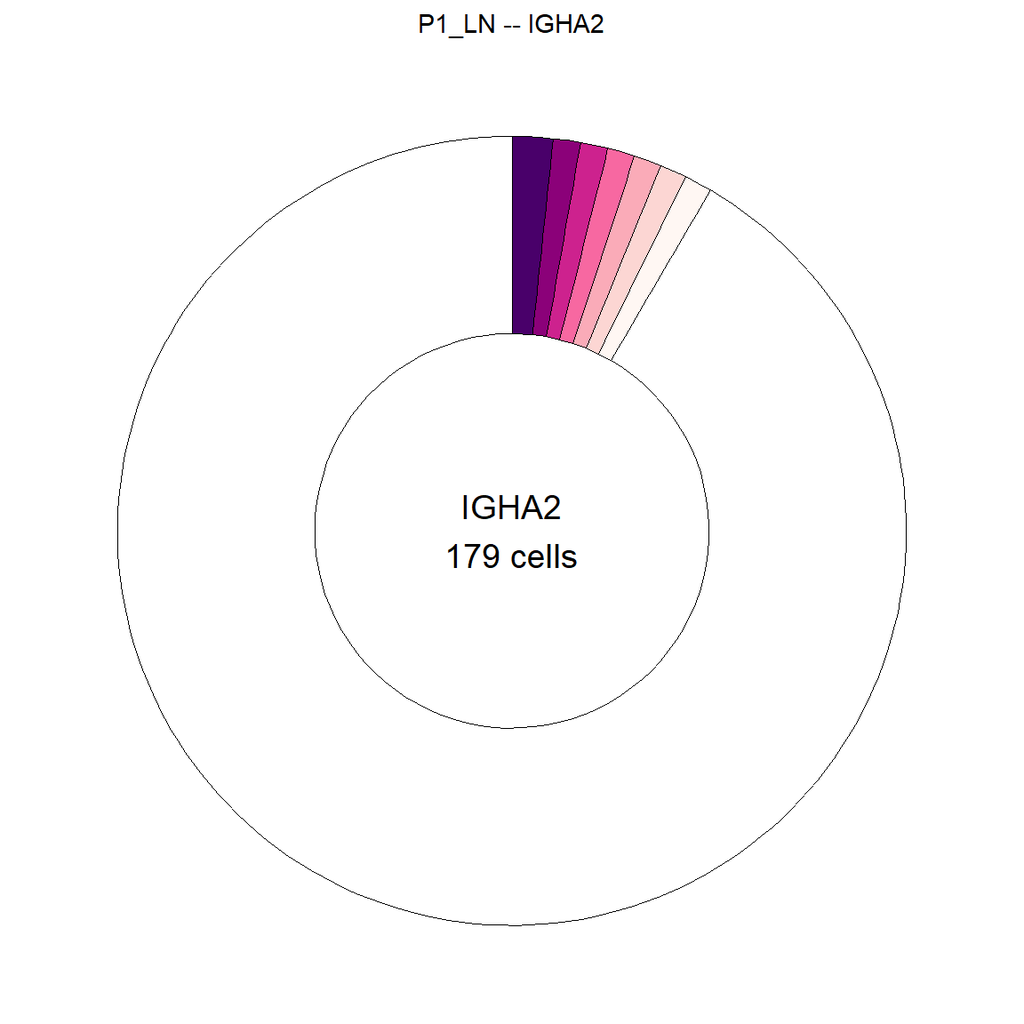

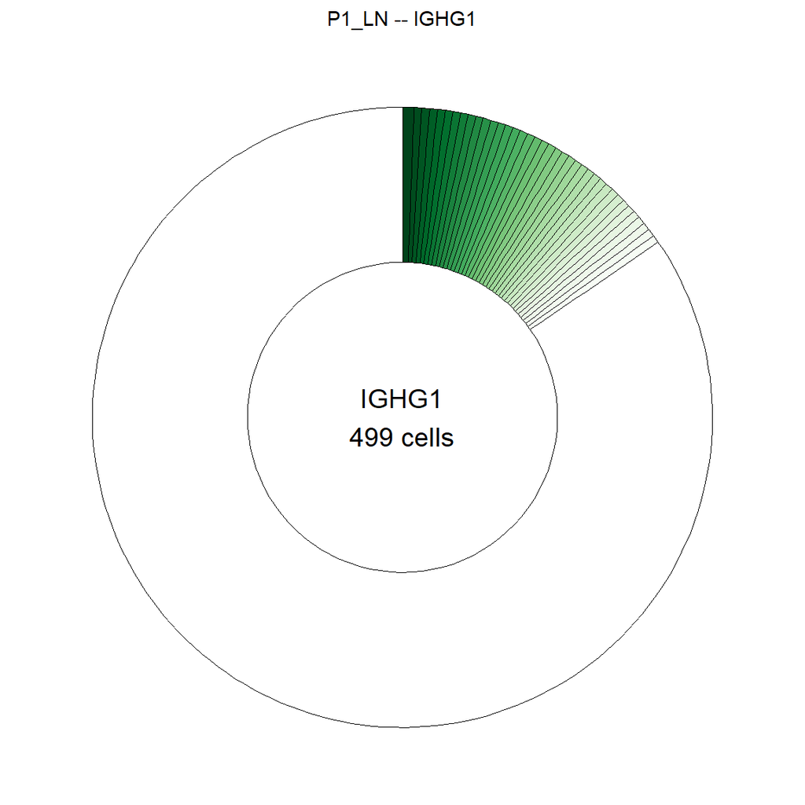

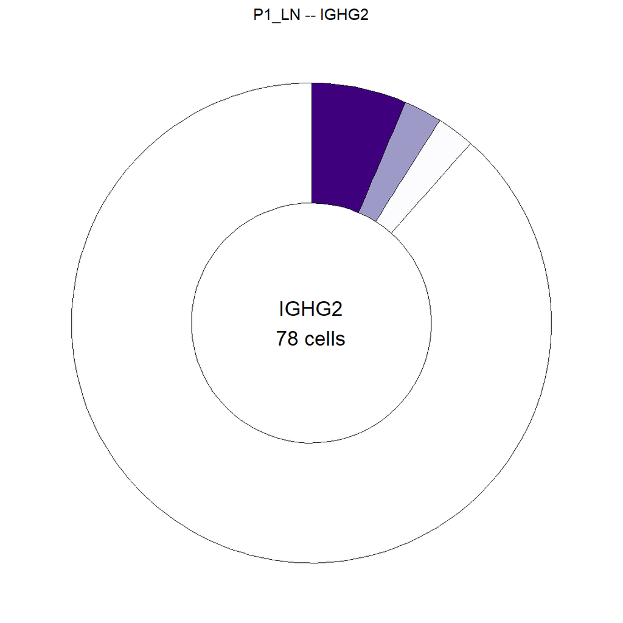

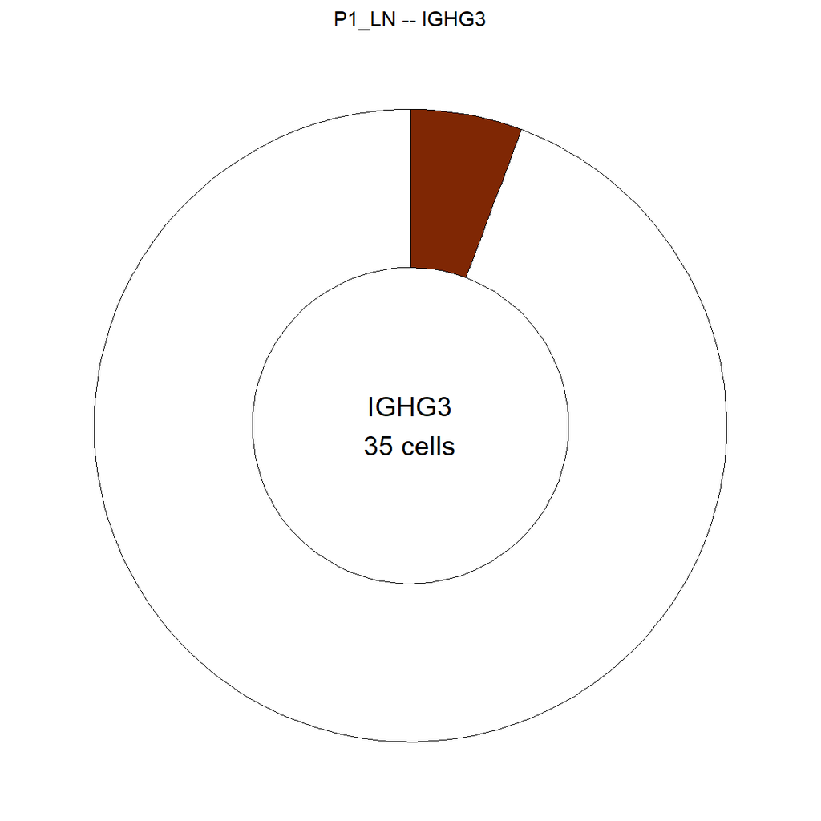

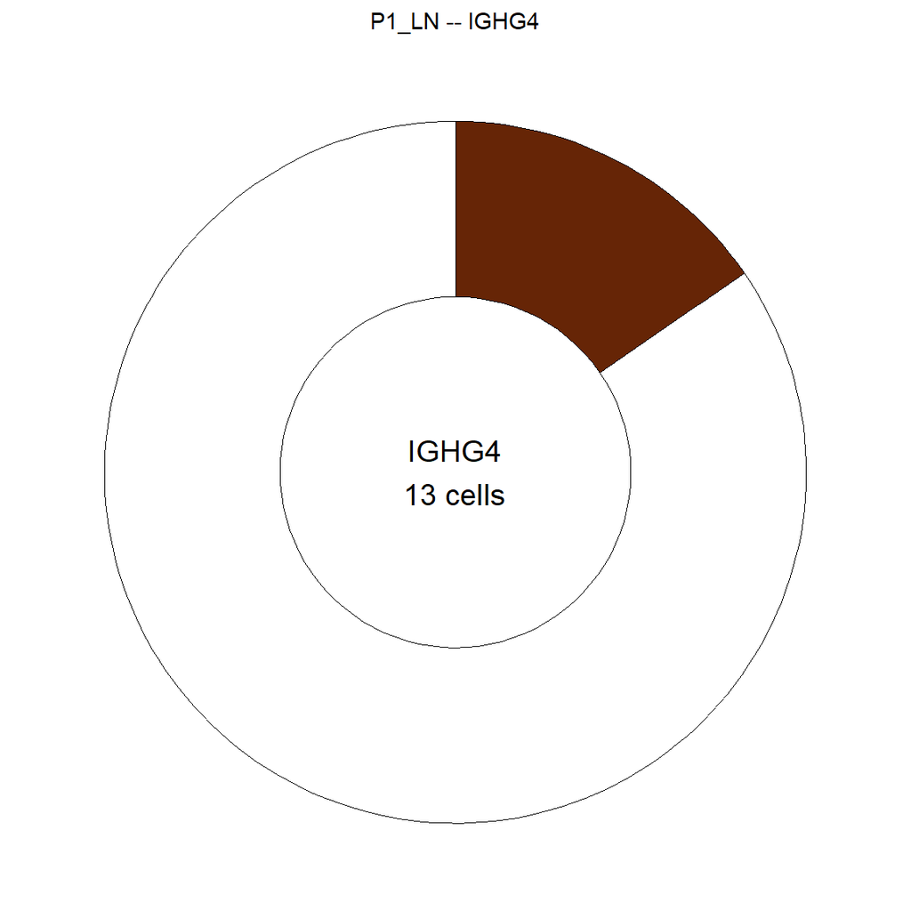

### 8.3.4 Per-isotype donuts – P1_PT

```r
iso_donuts_pt <- plot_isotype_donuts(bcr_annotated[["P1_PT"]], sample_name = "P1_PT")
```

```
## Building per-isotype donuts for: P1_PT
```

```
##   IGHD: 10 cells | 0 expanded clones
```

```
##   IGHM: 709 cells | 55 expanded clones
```

```
##   IGHA1: 134 cells | 13 expanded clones
```

```
##   IGHA2: 28 cells | 0 expanded clones
```

```
##   IGHG1: 2948 cells | 199 expanded clones
```

```
##   IGHG2: 212 cells | 23 expanded clones
```

```
##   IGHG3: 103 cells | 17 expanded clones
```

```
##   IGHG4: 23 cells | 1 expanded clones
```

```
##   Skipping IGHE -- only 2 cells (min_cells = 5)
```

```
## plot_isotype_donuts complete. Isotypes plotted: IGHD, IGHM, IGHA1, IGHA2, IGHG1, IGHG2, IGHG3, IGHG4
```

```r
for (iso in names(iso_donuts_pt)) {
  print(iso_donuts_pt[[iso]]$all_clones)
}
```

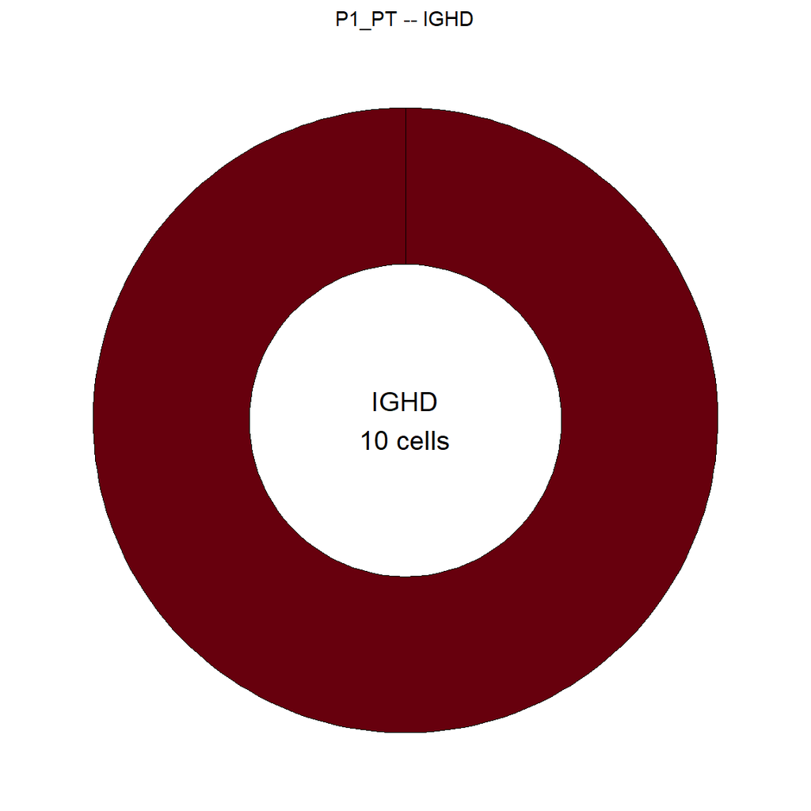

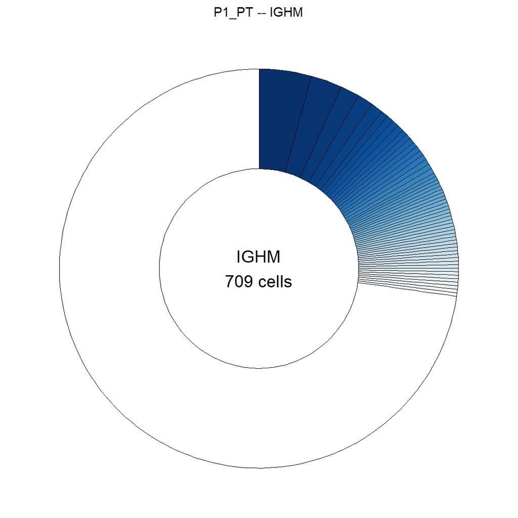

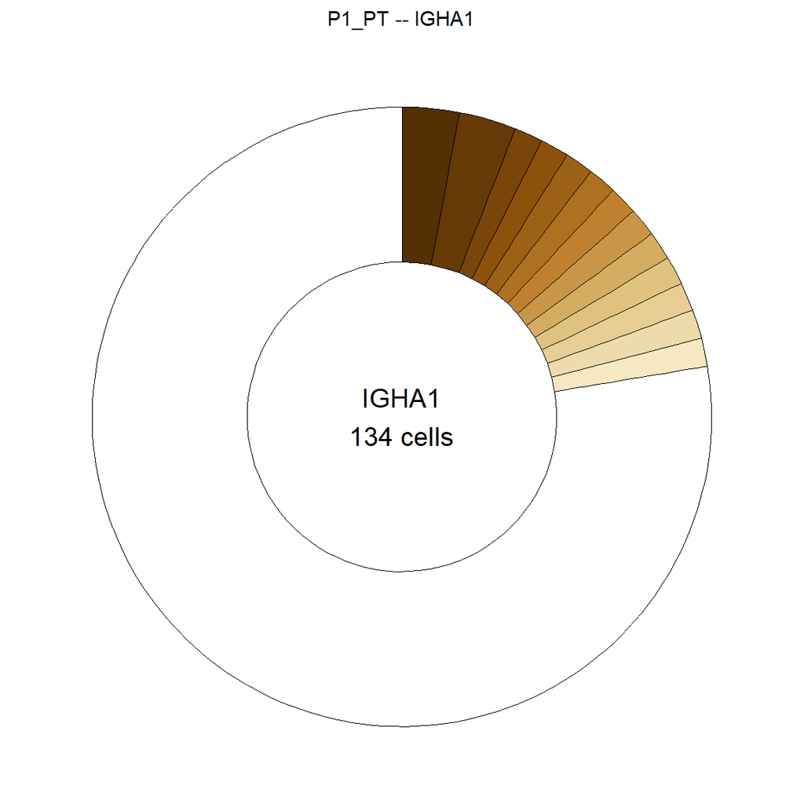

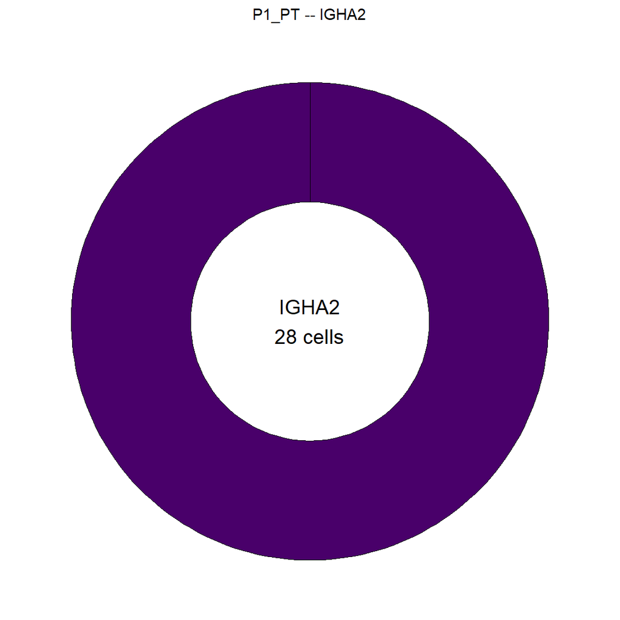

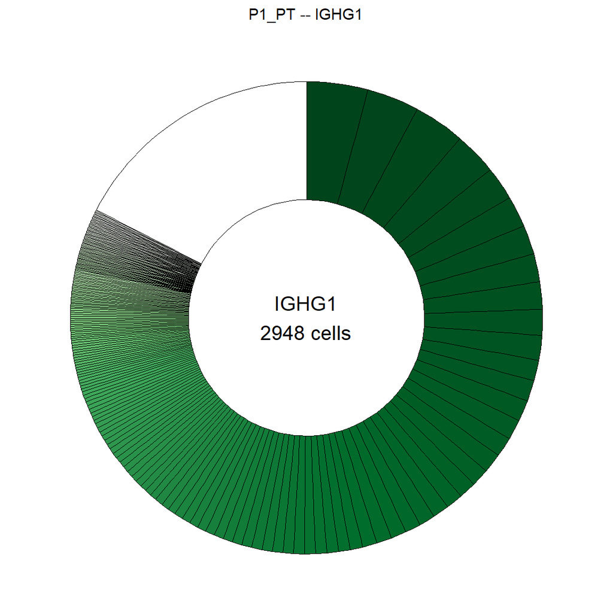

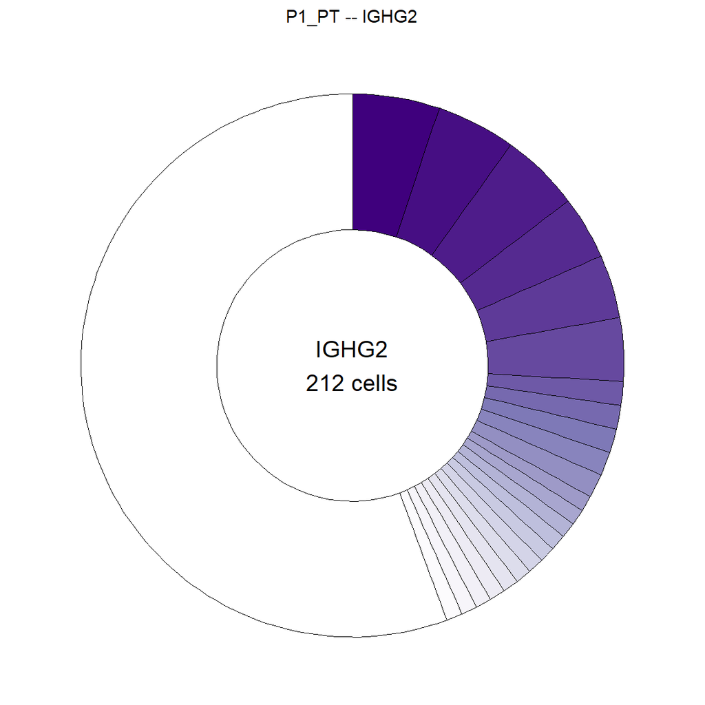

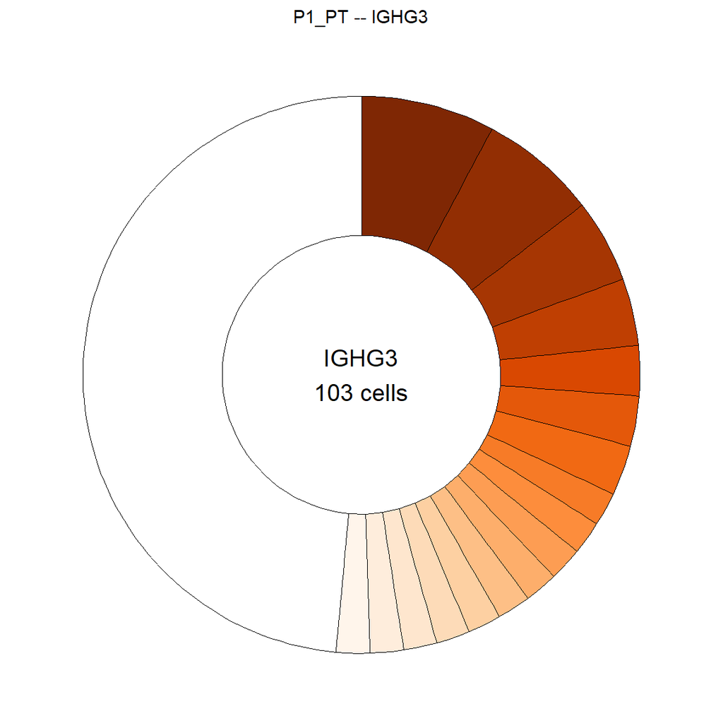

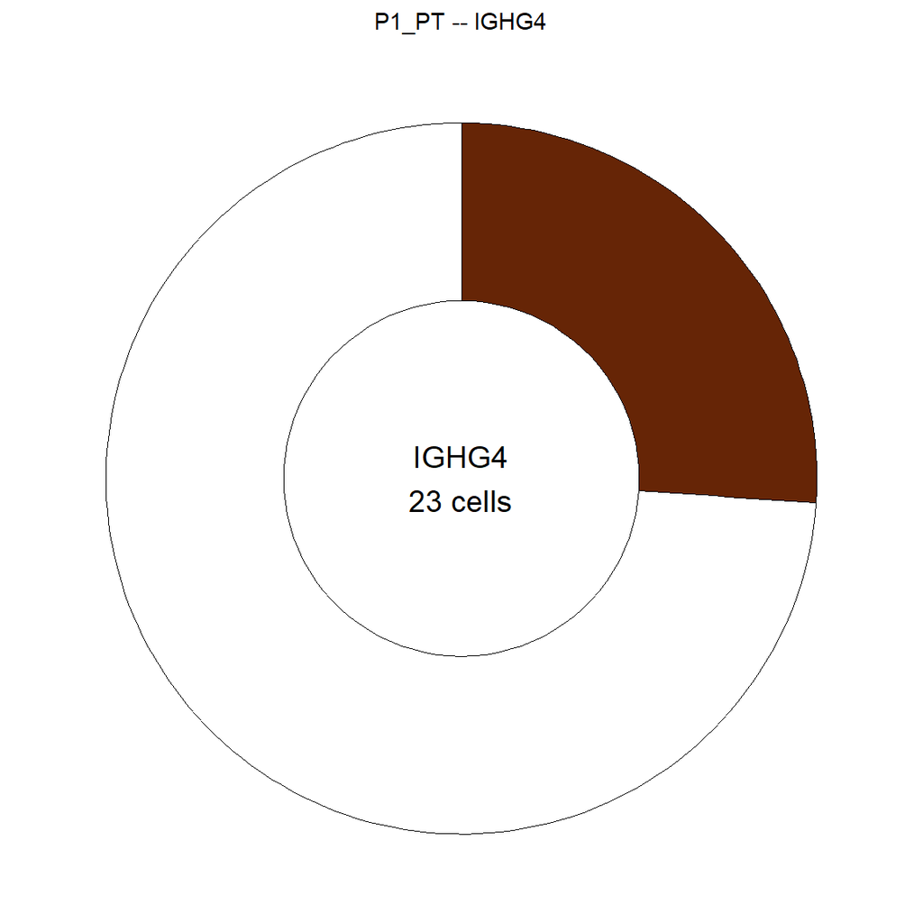

### 8.3.5 Per-cluster donuts – P1_LN

Clusters with fewer than 10 cells are skipped automatically. BCR cells that did not match a Seurat barcode (NA cell type) are excluded from this section.

```r
cluster_donuts_ln <- plot_cluster_donuts(
  bcr_annotated[["P1_LN"]],
  sample_name   = "P1_LN",
  cell_type_col = "cell_type"
)
```

```
## Building per-cluster donuts for: P1_LN
```

```
##   Clusters found: Naive, MBC_Basal, MBC_CR2pos, MBC_Atypical, GC, GC_Cycling, PC, Plasmablast
```

```
## Building combined donut for: P1_LN / Naive
```

```
##   Total cells: 517 | Expanded clones: 17
```

```
##   Done: Naive (1041 cells)
```

```
## Building combined donut for: P1_LN / MBC_Basal
```

```
##   Total cells: 1216 | Expanded clones: 78
```

```
##   Done: MBC_Basal (2460 cells)
```

```
## Building combined donut for: P1_LN / MBC_CR2pos
```

```
##   Total cells: 231 | Expanded clones: 4
```

```
##   Done: MBC_CR2pos (465 cells)
```

```
## Building combined donut for: P1_LN / MBC_Atypical
```

```
##   Total cells: 66 | Expanded clones: 1
```

```
##   Done: MBC_Atypical (131 cells)
```

```
## Building combined donut for: P1_LN / GC
```

```
##   Total cells: 5 | Expanded clones: 1
```

```
##   Done: GC (10 cells)
```

```
##   Skipping 'GC_Cycling' -- only 9 cells (min_cells = 10)
```

```
## Building combined donut for: P1_LN / PC
```

```
##   Total cells: 10 | Expanded clones: 0
```

```
##   Done: PC (20 cells)
```

```
##   Skipping 'Plasmablast' -- only 2 cells (min_cells = 10)
```

```
## plot_cluster_donuts complete. Clusters plotted: Naive, MBC_Basal, MBC_CR2pos, MBC_Atypical, GC, PC
```

```r
for (cl in names(cluster_donuts_ln)) {
  print(cluster_donuts_ln[[cl]]$all_clones)
}
```

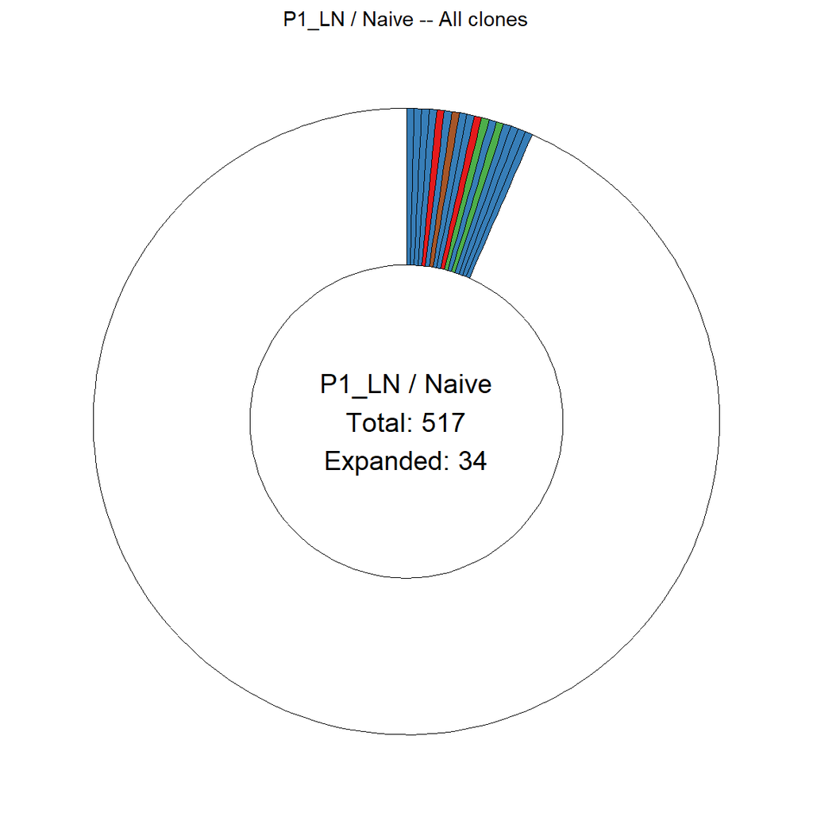

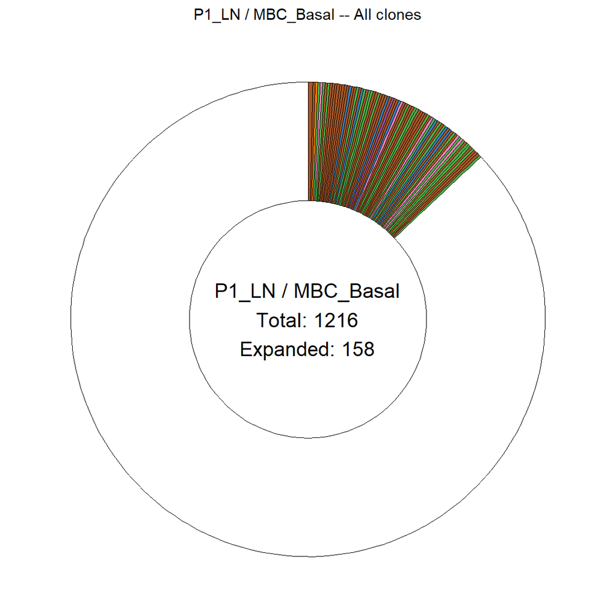

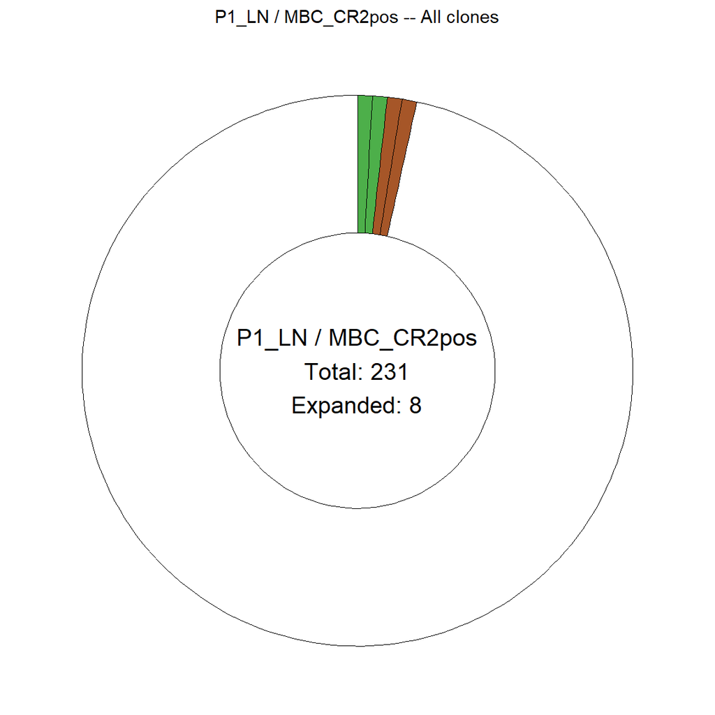

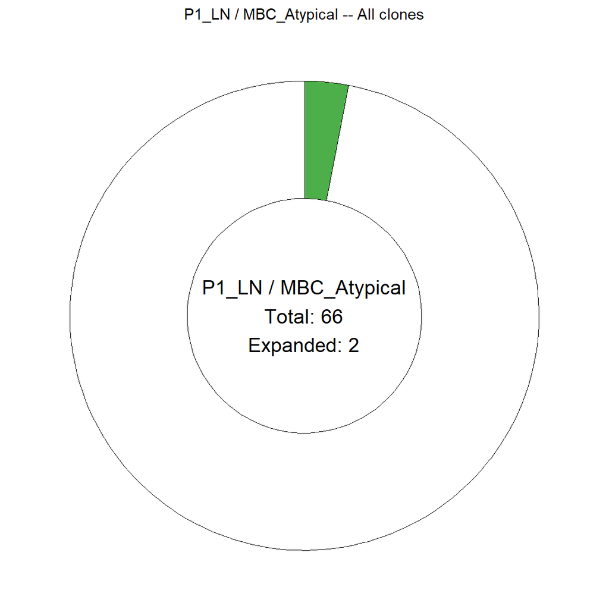

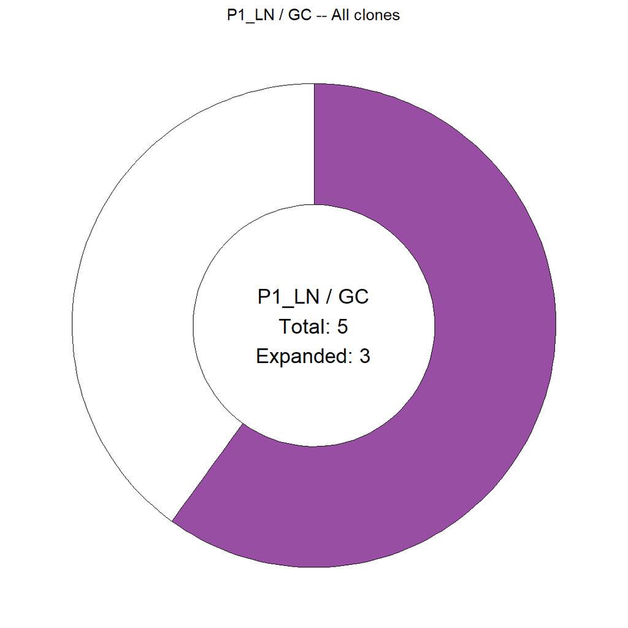

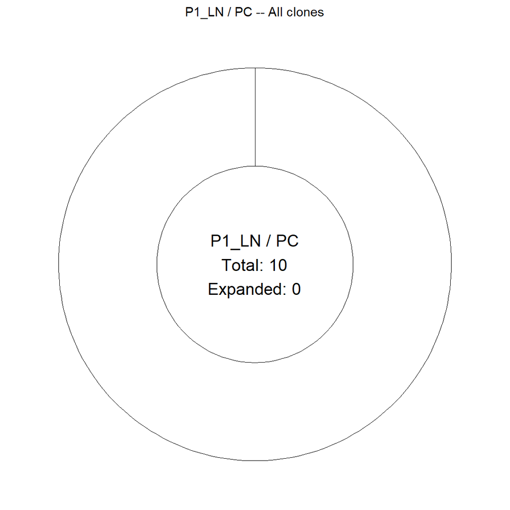

### 8.3.6 Per-cluster donuts – P1_PT

```r
cluster_donuts_pt <- plot_cluster_donuts(
  bcr_annotated[["P1_PT"]],
  sample_name   = "P1_PT",
  cell_type_col = "cell_type"
)
```

```
## Building per-cluster donuts for: P1_PT
```

```
##   Clusters found: Naive, MBC_Basal, MBC_CR2pos, MBC_Atypical, GC, GC_Cycling, PC, PC_2, Plasmablast, Unsure
```

```
## Building combined donut for: P1_PT / Naive
```

```
##   Total cells: 143 | Expanded clones: 1
```

```
##   Done: Naive (289 cells)
```

```
## Building combined donut for: P1_PT / MBC_Basal
```

```
##   Total cells: 644 | Expanded clones: 35
```

```
##   Done: MBC_Basal (1399 cells)
```

```
## Building combined donut for: P1_PT / MBC_CR2pos
```

```
##   Total cells: 54 | Expanded clones: 1
```

```
##   Done: MBC_CR2pos (114 cells)
```

```
## Building combined donut for: P1_PT / MBC_Atypical
```

```
##   Total cells: 778 | Expanded clones: 92
```

```
##   Done: MBC_Atypical (1735 cells)
```

```
## Building combined donut for: P1_PT / GC
```

```
##   Total cells: 232 | Expanded clones: 42
```

```
##   Done: GC (540 cells)
```

```
## Building combined donut for: P1_PT / GC_Cycling
```

```
##   Total cells: 301 | Expanded clones: 56
```

```
##   Done: GC_Cycling (640 cells)
```

```
## Building combined donut for: P1_PT / PC
```

```
##   Total cells: 647 | Expanded clones: 86
```

```
##   Done: PC (1309 cells)
```

```
## Building combined donut for: P1_PT / PC_2
```

```
##   Total cells: 206 | Expanded clones: 37
```

```
##   Done: PC_2 (419 cells)
```

```
## Building combined donut for: P1_PT / Plasmablast
```

```
##   Total cells: 125 | Expanded clones: 20
```

```
##   Done: Plasmablast (257 cells)
```

```
##   Skipping 'Unsure' -- only 8 cells (min_cells = 10)
```

```
## plot_cluster_donuts complete. Clusters plotted: Naive, MBC_Basal, MBC_CR2pos, MBC_Atypical, GC, GC_Cycling, PC, PC_2, Plasmablast
```

```r
for (cl in names(cluster_donuts_pt)) {
  print(cluster_donuts_pt[[cl]]$all_clones)
}
```

[output not shown]

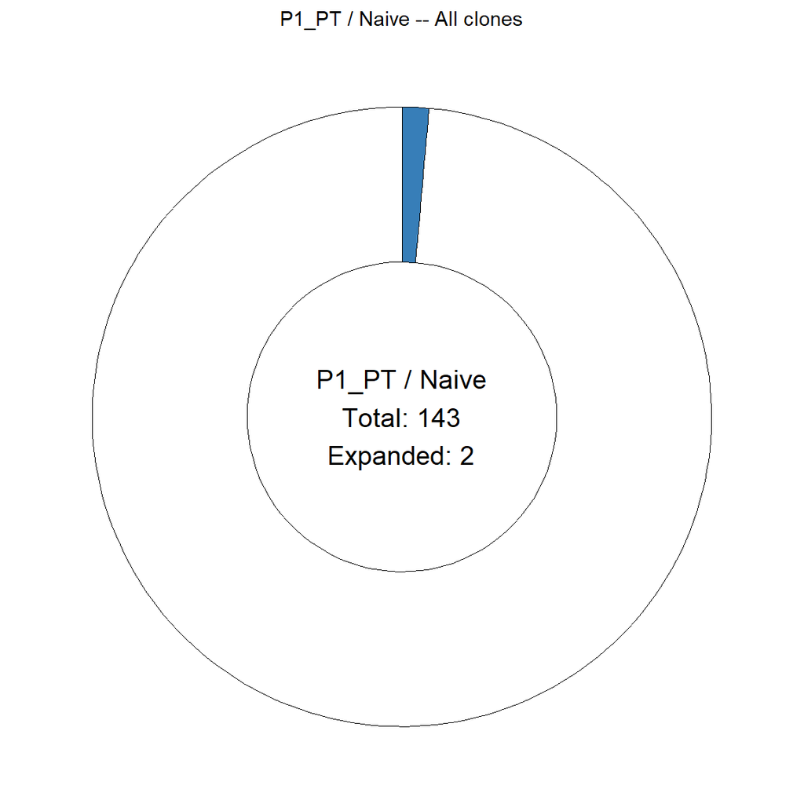

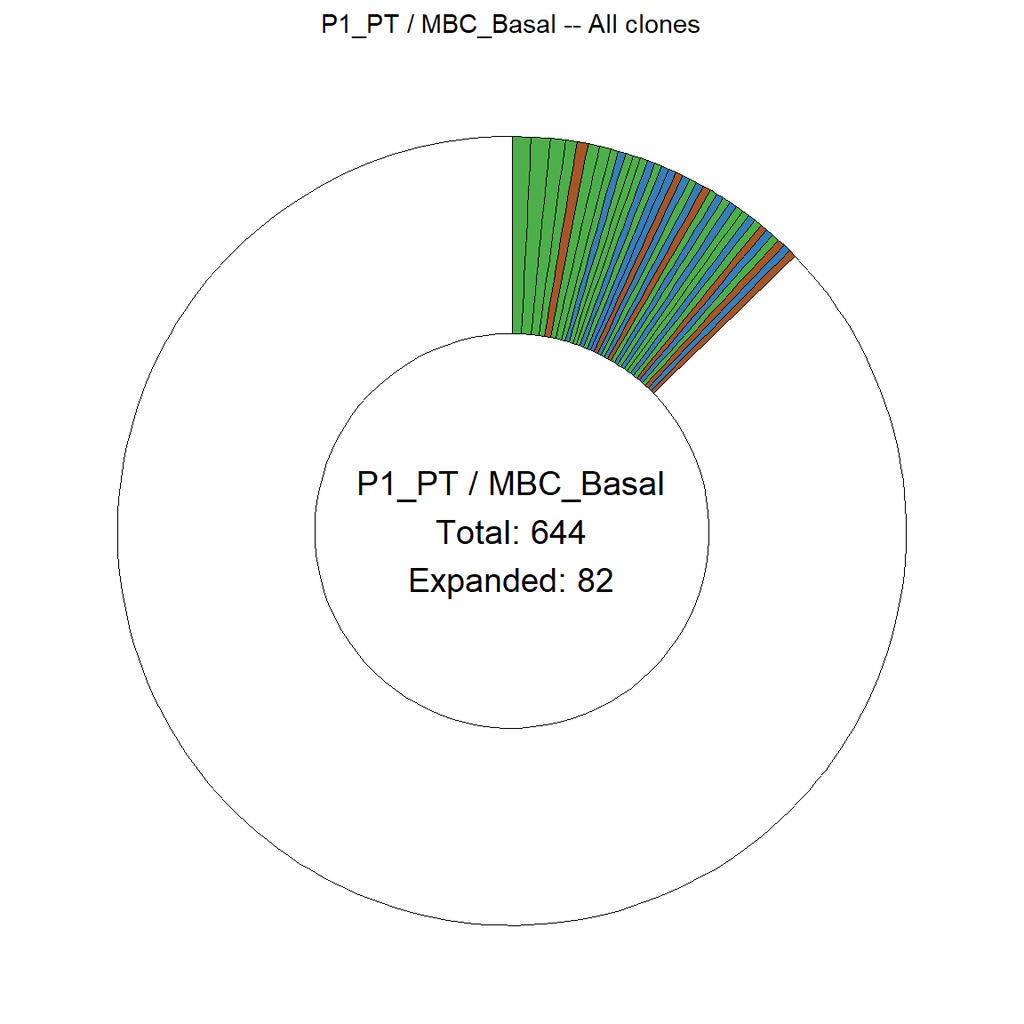

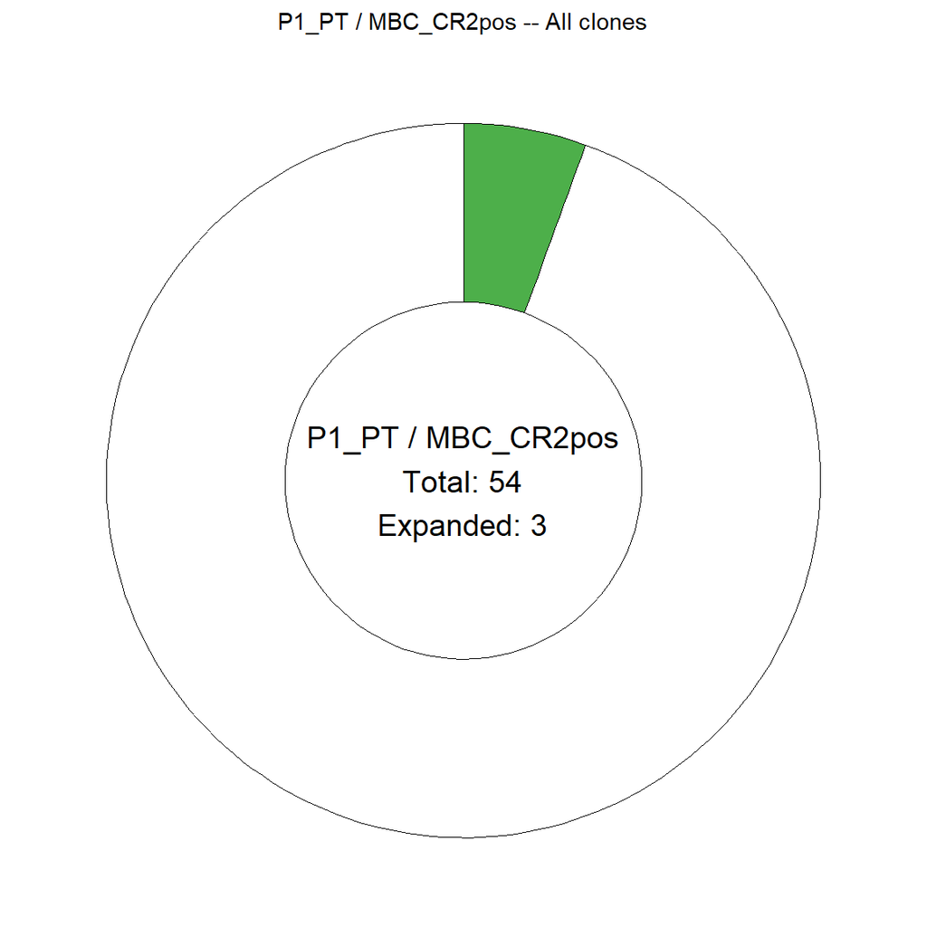

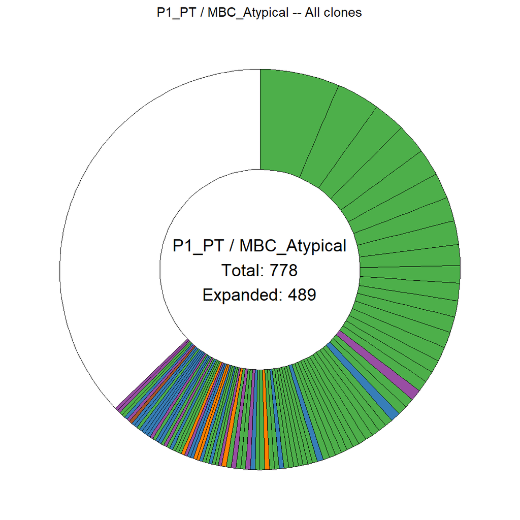

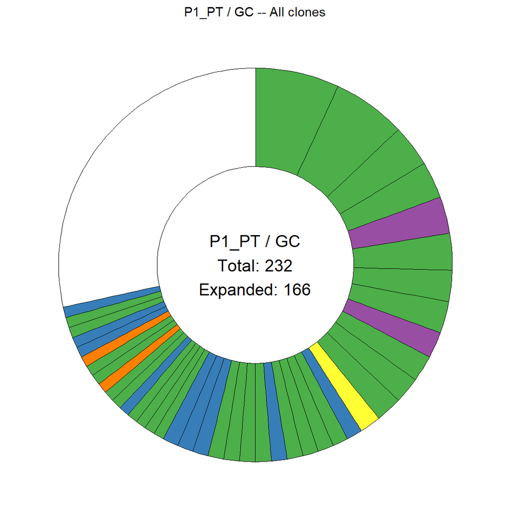

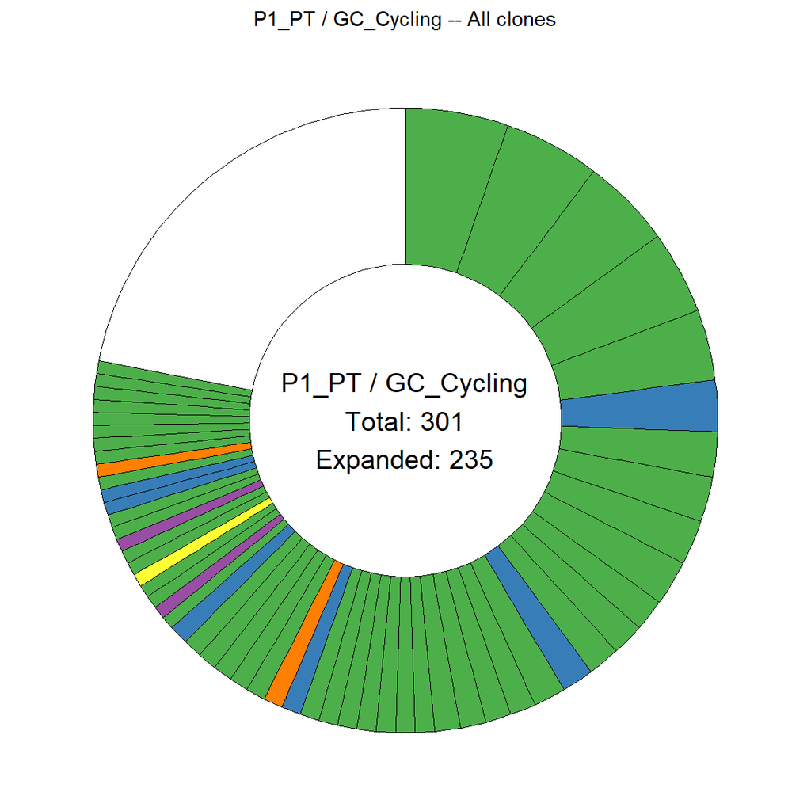